# IODS course project

## Principal component analysis without scaling the variables

Perform principal component analysis (PCA) on the raw (non-standardized) human data.

Show the variability captured by the principal components.

Draw a biplot displaying the observations by the first two principal components (PC1 coordinate in x-axis, PC2 coordinate in y-axis), along with arrows representing the original variables. (0-2 points)

```r
# perform principal component analysis (with the SVD method) without scaling
not_scaled_human <- prcomp(human)

summary(not_scaled_human)
```

```
## Importance of components:
##                              PC1      PC2   PC3   PC4   PC5   PC6    PC7    PC8
## Standard deviation     1.854e+04 185.5219 25.19 11.45 3.766 1.566 0.1912 0.1591
## Proportion of Variance 9.999e-01   0.0001  0.00  0.00 0.000 0.000 0.0000 0.0000
## Cumulative Proportion  9.999e-01   1.0000  1.00  1.00 1.000 1.000 1.0000 1.0000
```

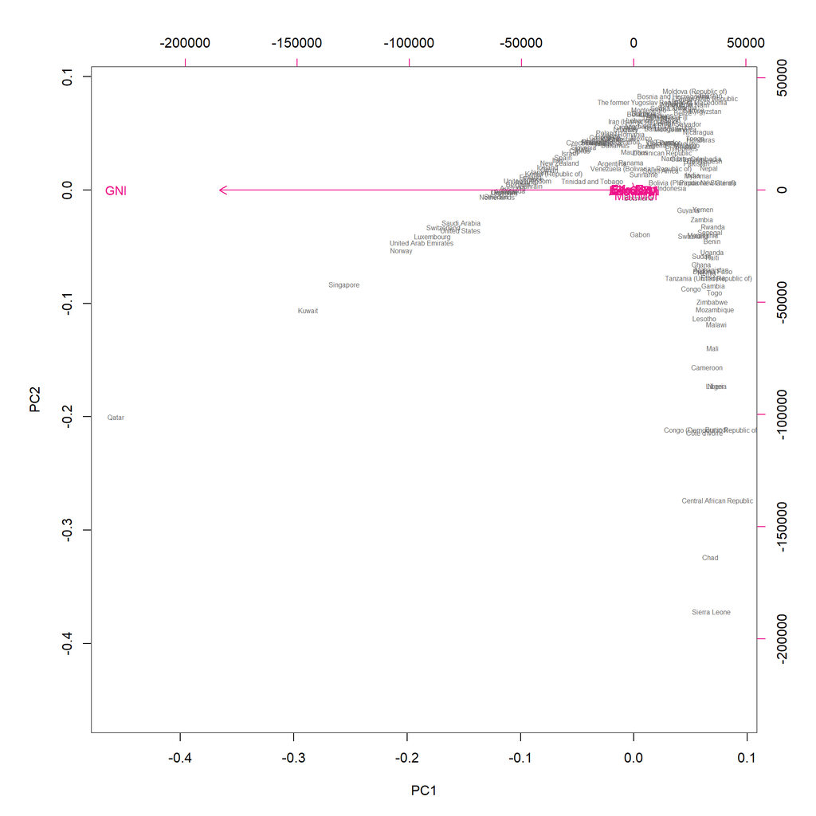

```r
# draw a biplot of the principal component representation and the original variables
biplot(not_scaled_human, choices = 1:2, cex = c(0.5, 0.9), col = c("grey40", "deeppink2"))
```

This doesn’t seem to work as the only arrow we see represents ‘GNI’. All of the other arrows and variable names are clustered in the in one small mess.

Summaries of the unscaled data:

```r
# summary of the human data
summary(human)
```

```
##     Edu2.FM          Labo.FM          Life.Exp        Edu.Exp
##  Min.   :0.1717   Min.   :0.1857   Min.   :49.00   Min.   : 5.40
##  1st Qu.:0.7264   1st Qu.:0.5984   1st Qu.:66.30   1st Qu.:11.25
##  Median :0.9375   Median :0.7535   Median :74.20   Median :13.50
##  Mean   :0.8529   Mean   :0.7074   Mean   :71.65   Mean   :13.18
##  3rd Qu.:0.9968   3rd Qu.:0.8535   3rd Qu.:77.25   3rd Qu.:15.20
##  Max.   :1.4967   Max.   :1.0380   Max.   :83.50   Max.   :20.20
##       GNI            Mat.Mor         Ado.Birth         Parli.F
##  Min.   :   581   Min.   :   1.0   Min.   :  0.60   Min.   : 0.00
##  1st Qu.:  4198   1st Qu.:  11.5   1st Qu.: 12.65   1st Qu.:12.40
##  Median : 12040   Median :  49.0   Median : 33.60   Median :19.30
##  Mean   : 17628   Mean   : 149.1   Mean   : 47.16   Mean   :20.91
##  3rd Qu.: 24512   3rd Qu.: 190.0   3rd Qu.: 71.95   3rd Qu.:27.95
##  Max.   :123124   Max.   :1100.0   Max.   :204.80   Max.   :57.50
```

Here, ‘GNI’ has numerically a lot higher values than the other variables. Maybe that is why it is the only arrow present in the plot.

## Principal component analysis for scaled variables

Scaling the variables:

```r
# standardize the variables
human_std <- scale(human)

# print out summaries of the standardized variables
summary(human_std)
```

```
##     Edu2.FM           Labo.FM           Life.Exp          Edu.Exp
##  Min.   :-2.8189   Min.   :-2.6247   Min.   :-2.7188   Min.   :-2.7378
##  1st Qu.:-0.5233   1st Qu.:-0.5484   1st Qu.:-0.6425   1st Qu.:-0.6782
##  Median : 0.3503   Median : 0.2316   Median : 0.3056   Median : 0.1140
##  Mean   : 0.0000   Mean   : 0.0000   Mean   : 0.0000   Mean   : 0.0000
##  3rd Qu.: 0.5958   3rd Qu.: 0.7350   3rd Qu.: 0.6717   3rd Qu.: 0.7126
##  Max.   : 2.6646   Max.   : 1.6632   Max.   : 1.4218   Max.   : 2.4730
##       GNI             Mat.Mor          Ado.Birth          Parli.F
##  Min.   :-0.9193   Min.   :-0.6992   Min.   :-1.1325   Min.   :-1.8203
##  1st Qu.:-0.7243   1st Qu.:-0.6496   1st Qu.:-0.8394   1st Qu.:-0.7409
##  Median :-0.3013   Median :-0.4726   Median :-0.3298   Median :-0.1403
##  Mean   : 0.0000   Mean   : 0.0000   Mean   : 0.0000   Mean   : 0.0000
##  3rd Qu.: 0.3712   3rd Qu.: 0.1932   3rd Qu.: 0.6030   3rd Qu.: 0.6127
##  Max.   : 5.6890   Max.   : 4.4899   Max.   : 3.8344   Max.   : 3.1850
```

After scaling the variation seems to be more similar than before scaling.

Principal component analysis for scaled variables:

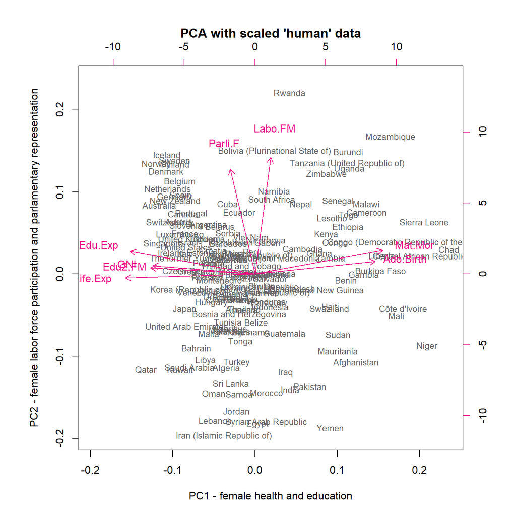

```r
# perform principal component analysis (with the SVD method)
pca_human <- prcomp(human_std)

# draw a biplot of the principal component representation and the original variables
biplot(pca_human, choices = 1:2, cex = c(0.8, 1), col = c("grey40", "deeppink2"), main = "PCA with scaled 'human' data", xlab = "PC1 - female health and education", ylab = "PC2 - female labor force participation and parlamentary representation")
```

PCA reduces the variables into principle components represented by the axes

- The variables in the plot are represented by the arrows.
- If I understood this correctly, in this case PC2 is affected by ‘Labo.FM’ and ‘Parli.F’, and the rest of the variables mainly affect PC1
  - If the variables are positively correlated, the angle between them is small
  - 90 degree angle - no correlation
  - 180 degree angle - negative correlation
- The results here are similar as observed based on the ‘ggpairs’ plot earlier:
  - ‘Edu.Exp’, ‘Life.Exp’, ‘GNI’ and ‘Edu2.FM’ are positively correlated with each other
  - ‘Parli.F’ and ‘Labo.FM’ are positively correlated with each other, but not really with other variables
  - ‘Mat.Mort’ and ‘Ado.Birth’ are positively with each other, and negatively correlated with ‘Edu.Exp’, ‘Life.Exp’, ‘GNI’ and ‘Edu2.FM’
- The observations that are more similar regarding these variables are clustered together
  - for example, Nordic countries appear very close to each other at the upper left corner

## PCA for the Tea time data

Loading the data and converting them to factors

```r
# loading the libraries
library(dplyr)
library(tidyr)
library(ggplot2)
library(tidyverse)
#loading the data and converting strings to factors
tea <- read.csv("https://raw.githubusercontent.com/KimmoVehkalahti/Helsinki-Open-Data-Science/master/datasets/tea.csv", stringsAsFactors = TRUE)
```

Exploring the data

```r
colnames(tea)
```

```
##  [1] "breakfast"        "tea.time"         "evening"          "lunch"
##  [5] "dinner"           "always"           "home"             "work"
##  [9] "tearoom"          "friends"          "resto"            "pub"
## [13] "Tea"              "How"              "sugar"            "how"
## [17] "where"            "price"            "age"              "sex"
## [21] "SPC"              "Sport"            "age_Q"            "frequency"
## [25] "escape.exoticism" "spirituality"     "healthy"          "diuretic"
## [29] "friendliness"     "iron.absorption"  "feminine"         "sophisticated"
## [33] "slimming"         "exciting"         "relaxing"         "effect.on.health"
```

```r
view(tea)

library(dplyr)
library(tidyr)
# column names to keep in the dataset, I added a few to the Exercise code...
keep_columns <- c("Tea", "How", "how", "sugar", "where", "lunch", "evening", "pub")

# select the 'keep_columns' to create a new dataset
tea_time <- dplyr::select(tea, keep_columns)
# look at the summaries and structure of the data
str(tea_time)
```

```
## 'data.frame':    300 obs. of  8 variables:
##  $ Tea    : Factor w/ 3 levels "black","Earl Grey",..: 1 1 2 2 2 2 2 1 2 1 ...
##  $ How    : Factor w/ 4 levels "alone","lemon",..: 1 3 1 1 1 1 1 3 3 1 ...
##  $ how    : Factor w/ 3 levels "tea bag","tea bag+unpackaged",..: 1 1 1 1 1 1 1 1 2 2 ...
##  $ sugar  : Factor w/ 2 levels "No.sugar","sugar": 2 1 1 2 1 1 1 1 1 1 ...
##  $ where  : Factor w/ 3 levels "chain store",..: 1 1 1 1 1 1 1 1 2 2 ...
##  $ lunch  : Factor w/ 2 levels "lunch","Not.lunch": 2 2 2 2 2 2 2 2 2 2 ...
##  $ evening: Factor w/ 2 levels "evening","Not.evening": 2 2 1 2 1 2 2 1 2 1 ...
##  $ pub    : Factor w/ 2 levels "Not.pub","pub": 1 1 1 1 1 1 1 1 1 1 ...
```

```r
summary(tea_time)
```

```
##         Tea         How                      how           sugar
##  black    : 74   alone:195   tea bag           :170   No.sugar:155
##  Earl Grey:193   lemon: 33   tea bag+unpackaged: 94   sugar   :145
##  green    : 33   milk : 63   unpackaged        : 36
##                  other:  9
##                   where           lunch            evening         pub
##  chain store         :192   lunch    : 44   evening    :103   Not.pub:237
##  chain store+tea shop: 78   Not.lunch:256   Not.evening:197   pub    : 63
##  tea shop            : 30
##
```

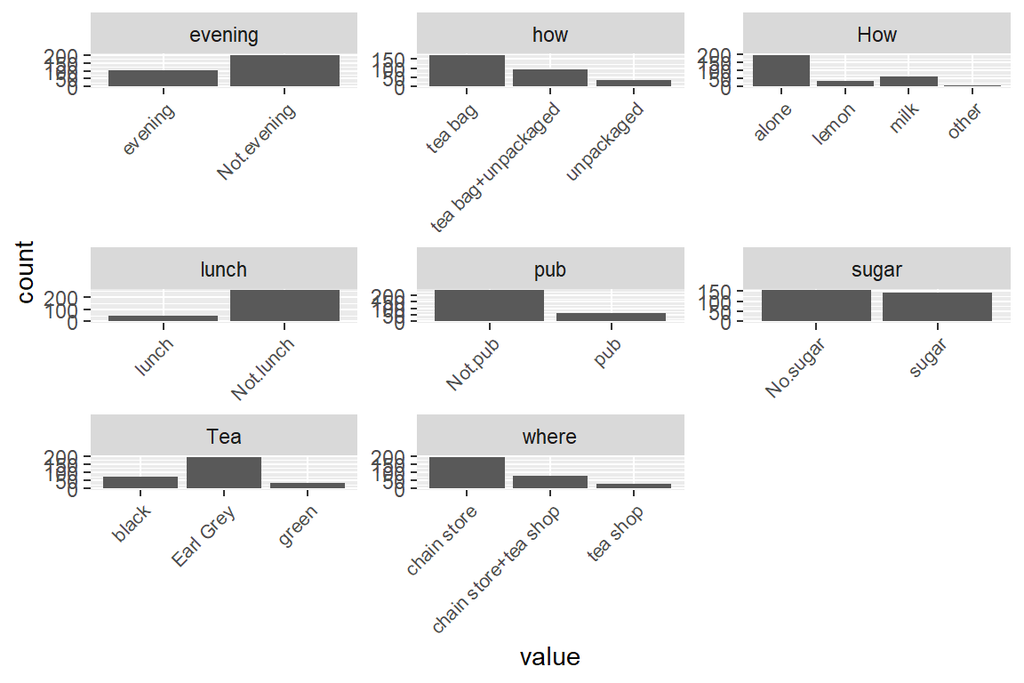

```r
# visualize the dataset
library(ggplot2)
pivot_longer(tea_time, cols = everything()) %>%
  ggplot(aes(value)) + facet_wrap("name", scales = "free") +
  geom_bar() + theme(axis.text.x = element_text(angle = 45, hjust = 1, size = 8))
```

I also tried the visualization of the whole ‘tea’ data but that did not work with ‘geom_bar’, as ‘age’ was numeric. When that was removed, the visualization of the whole data did not really work as the plots were too small to see the bars.

```r
library(FactoMineR)
```

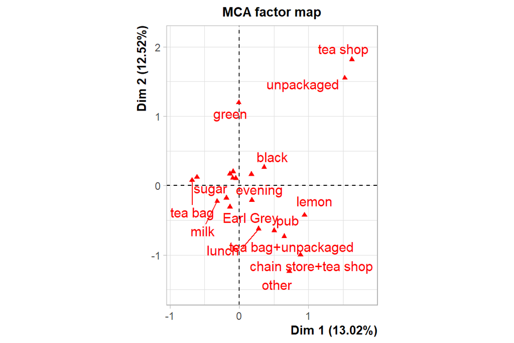

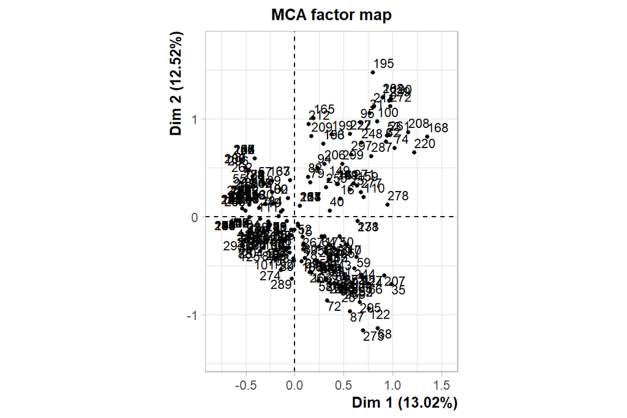

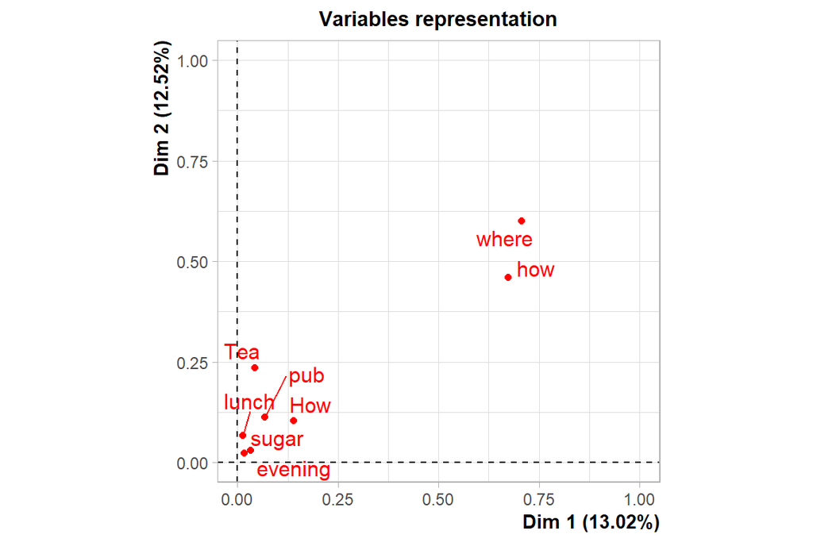

```r
# multiple correspondence analysis
library(FactoMineR)
mca <- MCA(tea_time, graph = T)
```

```r
# summary of the model
summary(mca)
```

```
##
## Call:
## MCA(X = tea_time, graph = T)
##
##
## Eigenvalues
##                        Dim.1   Dim.2   Dim.3   Dim.4   Dim.5   Dim.6   Dim.7
## Variance               0.212   0.203   0.173   0.147   0.139   0.136   0.115
## % of var.             13.020  12.523  10.654   9.065   8.553   8.371   7.053
## Cumulative % of var.  13.020  25.542  36.196  45.262  53.815  62.185  69.238
##                        Dim.8   Dim.9  Dim.10  Dim.11  Dim.12  Dim.13
## Variance               0.107   0.105   0.096   0.081   0.065   0.046
## % of var.              6.607   6.448   5.938   4.974   3.976   2.819
## Cumulative % of var.  75.846  82.294  88.232  93.205  97.181 100.000
##
## Individuals (the 10 first)
##                       Dim.1    ctr   cos2    Dim.2    ctr   cos2    Dim.3
## 1                  | -0.404  0.257  0.188 |  0.243  0.096  0.068 | -0.224
## 2                  | -0.369  0.215  0.109 |  0.219  0.078  0.038 | -0.644
## 3                  | -0.366  0.211  0.188 |  0.091  0.014  0.012 |  0.086
## 4                  | -0.538  0.456  0.521 |  0.084  0.012  0.013 |  0.182
## 5                  | -0.366  0.211  0.188 |  0.091  0.014  0.012 |  0.086
## 6                  | -0.441  0.306  0.360 |  0.179  0.053  0.059 | -0.156
## 7                  | -0.441  0.306  0.360 |  0.179  0.053  0.059 | -0.156
## 8                  | -0.295  0.137  0.061 |  0.131  0.028  0.012 | -0.402
## 9                  |  0.265  0.110  0.050 | -0.474  0.367  0.160 | -0.464
## 10                 |  0.536  0.452  0.193 | -0.285  0.133  0.054 | -0.546
##                       ctr   cos2
## 1                   0.097  0.058 |
## 2                   0.799  0.331 |
## 3                   0.014  0.010 |
## 4                   0.064  0.060 |
## 5                   0.014  0.010 |
## 6                   0.047  0.045 |
## 7                   0.047  0.045 |
## 8                   0.312  0.113 |
## 9                   0.414  0.153 |
## 10                  0.573  0.200 |
##
## Categories (the 10 first)
```

[output cut: 18 more lines]

```
## other               -3.762 |  -2.669  15.430   0.220  -8.116 |
## tea bag              1.500 |   0.054   0.118   0.004   1.063 |
## tea bag+unpackaged  -8.542 |  -0.296   1.978   0.040  -3.454 |
## unpackaged           9.905 |   0.518   2.327   0.037   3.309 |
##
## Categorical variables (eta2)
##                      Dim.1 Dim.2 Dim.3
## Tea                | 0.043 0.235 0.330 |
## How                | 0.139 0.103 0.323 |
## how                | 0.673 0.460 0.061 |
## sugar              | 0.032 0.029 0.316 |
## where              | 0.707 0.600 0.083 |
## lunch              | 0.013 0.066 0.079 |
## evening            | 0.017 0.023 0.146 |
## pub                | 0.068 0.112 0.047 |
```

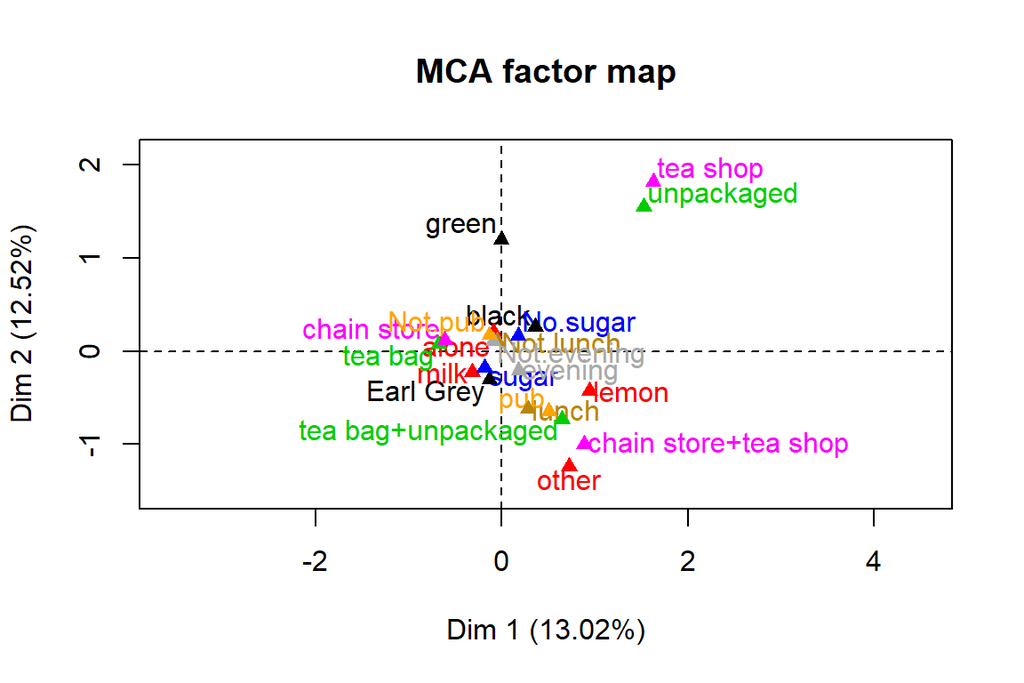

```r
# visualize MCA
plot(mca, invisible=c("ind"), graph.type = "classic", habillage = "quali")
```

- Based on the MCA factor plot, for example tea shop is associated with unpackaged tea, makes sense

# Analysis of longitudinal data

## RATSL dataset

### Loading the RATS

Loading the RATSL dataset from local folder

```r
library(readr)
library(dplyr)
library(tidyr)
RATSL <- read.csv("data/ratsl.csv")

class(RATSL)
```

```
## [1] "data.frame"
```

```r
ls(RATSL)
```

```
## [1] "Group"  "ID"     "Time"   "WD"     "Weight"
```

### Exploring the RATS

We first explore the RATSL dataset briefly:

```r
str(RATSL)
```

```
## 'data.frame':    176 obs. of  5 variables:
##  $ ID    : int  1 2 3 4 5 6 7 8 9 10 ...
##  $ Group : int  1 1 1 1 1 1 1 1 2 2 ...
##  $ WD    : chr  "WD1" "WD1" "WD1" "WD1" ...
##  $ Weight: int  240 225 245 260 255 260 275 245 410 405 ...
##  $ Time  : int  1 1 1 1 1 1 1 1 1 1 ...
```

```r
summary(RATSL)
```

```
##        ID            Group           WD                Weight
##  Min.   : 1.00   Min.   :1.00   Length:176         Min.   :225.0
##  1st Qu.: 4.75   1st Qu.:1.00   Class :character   1st Qu.:267.0
##  Median : 8.50   Median :1.50   Mode  :character   Median :344.5
##  Mean   : 8.50   Mean   :1.75                      Mean   :384.5
##  3rd Qu.:12.25   3rd Qu.:2.25                      3rd Qu.:511.2
##  Max.   :16.00   Max.   :3.00                      Max.   :628.0
##       Time
##  Min.   : 1.00
##  1st Qu.:15.00
##  Median :36.00
##  Mean   :33.55
##  3rd Qu.:50.00
##  Max.   :64.00
```

```r
glimpse(RATSL)
```

```
## Rows: 176
## Columns: 5
## $ ID     <int> 1, 2, 3, 4, 5, 6, 7, 8, 9, 10, 11, 12, 13, 14, 15, 16, 1, 2, 3,…
## $ Group  <int> 1, 1, 1, 1, 1, 1, 1, 1, 2, 2, 2, 2, 3, 3, 3, 3, 1, 1, 1, 1, 1, …
## $ WD     <chr> "WD1", "WD1", "WD1", "WD1", "WD1", "WD1", "WD1", "WD1", "WD1", …
## $ Weight <int> 240, 225, 245, 260, 255, 260, 275, 245, 410, 405, 445, 555, 470…
## $ Time   <int> 1, 1, 1, 1, 1, 1, 1, 1, 1, 1, 1, 1, 1, 1, 1, 1, 8, 8, 8, 8, 8, …
```

I tried to keep the ID and Group as factor, but after reading the data they are always back to integer…

I will change them now here…

```r
RATSL$ID <- as.factor(RATSL$ID)
RATSL$Group <- as.factor(RATSL$Group)

glimpse(RATSL) # ID and Group are factors now
```

```
## Rows: 176
## Columns: 5
## $ ID     <fct> 1, 2, 3, 4, 5, 6, 7, 8, 9, 10, 11, 12, 13, 14, 15, 16, 1, 2, 3,…
## $ Group  <fct> 1, 1, 1, 1, 1, 1, 1, 1, 2, 2, 2, 2, 3, 3, 3, 3, 1, 1, 1, 1, 1, …
## $ WD     <chr> "WD1", "WD1", "WD1", "WD1", "WD1", "WD1", "WD1", "WD1", "WD1", …
## $ Weight <int> 240, 225, 245, 260, 255, 260, 275, 245, 410, 405, 445, 555, 470…
## $ Time   <int> 1, 1, 1, 1, 1, 1, 1, 1, 1, 1, 1, 1, 1, 1, 1, 1, 8, 8, 8, 8, 8, …
```

The original RATS dataset has data on the effect of three treatments on the weight of rats. The data has been taken in a time of 64 days. The measurements for weight for each day of scaling were in their own column. In the modified RATSL dataset the measurements have been put into a single column, with the day of observation as a new variable ‘Time’.

### Plotting the RATS

```r
#Access the package ggplot2
library(ggplot2)

glimpse(RATSL)
```

```
## Rows: 176
## Columns: 5
## $ ID     <fct> 1, 2, 3, 4, 5, 6, 7, 8, 9, 10, 11, 12, 13, 14, 15, 16, 1, 2, 3,…
## $ Group  <fct> 1, 1, 1, 1, 1, 1, 1, 1, 2, 2, 2, 2, 3, 3, 3, 3, 1, 1, 1, 1, 1, …
## $ WD     <chr> "WD1", "WD1", "WD1", "WD1", "WD1", "WD1", "WD1", "WD1", "WD1", …
## $ Weight <int> 240, 225, 245, 260, 255, 260, 275, 245, 410, 405, 445, 555, 470…
## $ Time   <int> 1, 1, 1, 1, 1, 1, 1, 1, 1, 1, 1, 1, 1, 1, 1, 1, 8, 8, 8, 8, 8, …
```

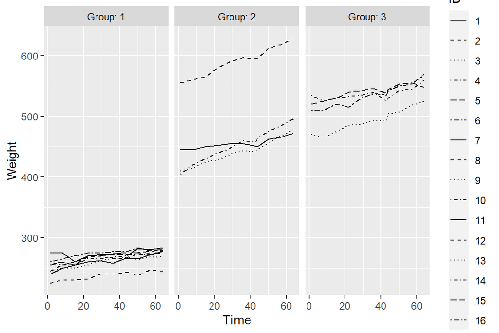

```r
# Drawing the plot
library(ggplot2)
ggplot(RATSL, aes(x = Time, y = Weight, linetype = ID)) +
  geom_line() +
  scale_linetype_manual(values = rep(1:10, times=4)) +
  facet_grid(. ~ Group, labeller = label_both) +
  scale_y_continuous(name = "Weight")
```

It seems that there are twice as many rats (8) as there are in groups 2 and 3 (4 rats)

Based on the plots, it seems that ther could be differences between the groups, at least between group 1 and the others. Between Group 2 and Group 3 less so. There also seems to be one ooutlier in Group 2.

We then standardise the data and plot again:

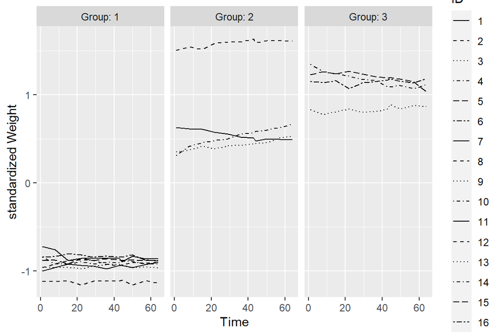

```r
library(dplyr)
library(tidyr)
# Standardise the variable Weight
RATSL <- RATSL %>%
  group_by(Time) %>%
  mutate(stdrats = scale(Weight)) %>%
  ungroup()


# Plot again with the standardised bprs
library(ggplot2)
ggplot(RATSL, aes(x = Time, y = stdrats, linetype = ID)) +
  geom_line() +
  scale_linetype_manual(values = rep(1:10, times=4)) +
  facet_grid(. ~ Group, labeller = label_both) +
  scale_y_continuous(name = "standardized Weight")
```

Combining the the IDs into a mean and adding SEMs

```r
summary(RATSL)
```

```
##        ID      Group       WD                Weight           Time
##  1      : 11   1:88   Length:176         Min.   :225.0   Min.   : 1.00
##  2      : 11   2:44   Class :character   1st Qu.:267.0   1st Qu.:15.00
##  3      : 11   3:44   Mode  :character   Median :344.5   Median :36.00
##  4      : 11                             Mean   :384.5   Mean   :33.55
##  5      : 11                             3rd Qu.:511.2   3rd Qu.:50.00
##  6      : 11                             Max.   :628.0   Max.   :64.00
##  (Other):110
##       stdrats.V1
##  Min.   :-1.1617911
##  1st Qu.:-0.9083890
##  Median :-0.2061907
##  Mean   : 0.0000000
##  3rd Qu.: 0.9234591
##  Max.   : 1.6329587
##
```

```r
# Number of rats (per group):
group_sizes <- data.frame(
  Group = c(1, 2, 3),
  n = c(8, 4, 4)
)

library(dplyr)
library(tidyr)
# Summary data with mean and standard error of weight by group and time
RATSS <- RATSL %>%
  group_by(Group, Time) %>%
  summarise(
    mean = mean(Weight),
    se = sd(Weight) / sqrt(n()) # this should calculate the se with the real n (8, 4 and 4)
    )
glimpse(RATSS)
```

```
## Rows: 33
## Columns: 4
## Groups: Group [3]
## $ Group <fct> 1, 1, 1, 1, 1, 1, 1, 1, 1, 1, 1, 2, 2, 2, 2, 2, 2, 2, 2, 2, 2, 2…
## $ Time  <int> 1, 8, 15, 22, 29, 36, 43, 44, 50, 57, 64, 1, 8, 15, 22, 29, 36, …
## $ mean  <dbl> 250.625, 255.000, 254.375, 261.875, 264.625, 265.000, 267.375, 2…
## $ se    <dbl> 5.381640, 4.629100, 4.057346, 4.808614, 3.909409, 4.166190, 3.87…
```

```r
# lets try with 8 for whole data

testi8 <- RATSL %>%
  group_by(Group, Time) %>%
  summarise(
    mean = mean(Weight),
    se = sd(Weight) / sqrt(8),
    .groups = 'drop'
    )

# lets try with 4 for whole data

testi4 <- RATSL %>%
  group_by(Group, Time) %>%
  summarise(
    mean = mean(Weight),
    se = sd(Weight) / sqrt(4),
    .groups = 'drop'
    )

glimpse(testi4)
```

```
## Rows: 33
## Columns: 4
## $ Group <fct> 1, 1, 1, 1, 1, 1, 1, 1, 1, 1, 1, 2, 2, 2, 2, 2, 2, 2, 2, 2, 2, 2…
## $ Time  <int> 1, 8, 15, 22, 29, 36, 43, 44, 50, 57, 64, 1, 8, 15, 22, 29, 36, …
## $ mean  <dbl> 250.625, 255.000, 254.375, 261.875, 264.625, 265.000, 267.375, 2…
## $ se    <dbl> 7.610789, 6.546537, 5.737953, 6.800407, 5.528740, 5.891883, 5.47…
```

```r
glimpse(testi8)
```

```
## Rows: 33
## Columns: 4
## $ Group <fct> 1, 1, 1, 1, 1, 1, 1, 1, 1, 1, 1, 2, 2, 2, 2, 2, 2, 2, 2, 2, 2, 2…
## $ Time  <int> 1, 8, 15, 22, 29, 36, 43, 44, 50, 57, 64, 1, 8, 15, 22, 29, 36, …
## $ mean  <dbl> 250.625, 255.000, 254.375, 261.875, 264.625, 265.000, 267.375, 2…
## $ se    <dbl> 5.381640, 4.629100, 4.057346, 4.808614, 3.909409, 4.166190, 3.87…
```

```r
glimpse(RATSS)
```

```
## Rows: 33
## Columns: 4
## Groups: Group [3]
## $ Group <fct> 1, 1, 1, 1, 1, 1, 1, 1, 1, 1, 1, 2, 2, 2, 2, 2, 2, 2, 2, 2, 2, 2…
## $ Time  <int> 1, 8, 15, 22, 29, 36, 43, 44, 50, 57, 64, 1, 8, 15, 22, 29, 36, …
## $ mean  <dbl> 250.625, 255.000, 254.375, 261.875, 264.625, 265.000, 267.375, 2…
## $ se    <dbl> 5.381640, 4.629100, 4.057346, 4.808614, 3.909409, 4.166190, 3.87…
```

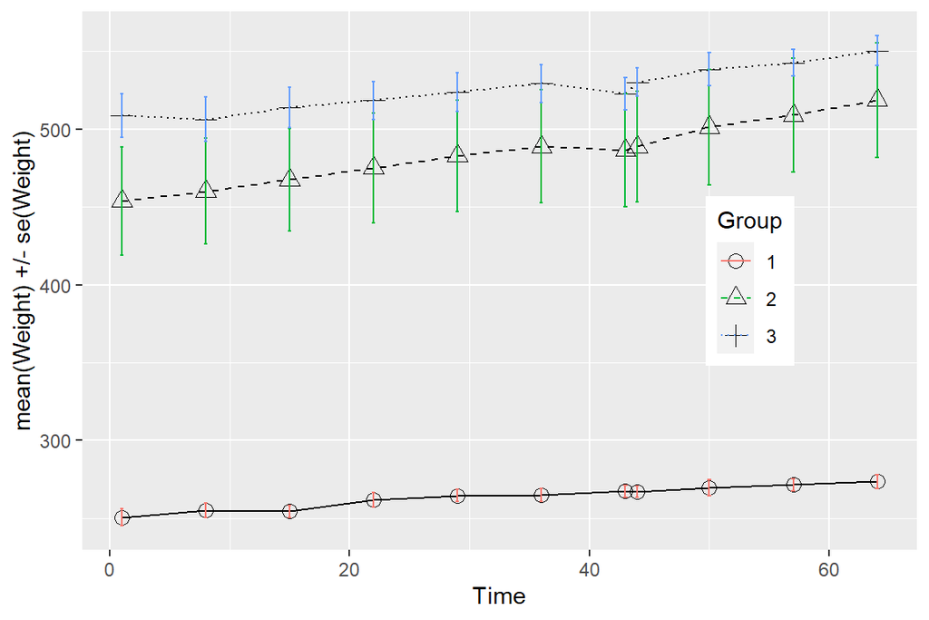

```r
# Looks like it matches, and sqrt(n()) did what it was meant to...


# Plot the mean profiles
library(ggplot2)
ggplot(RATSS, aes(x = Time, y = mean, linetype = Group, shape = Group)) +
  geom_line() +
  scale_linetype_manual(values = c(1,2,3)) +
  geom_point(size=3) +
  scale_shape_manual(values = c(1,2,3)) +
  geom_errorbar(aes(ymin=mean-se, ymax=mean+se, linetype="1",  color=Group), width=0.3) +
  theme(legend.position = c(0.8,0.5)) +
  scale_y_continuous(name = "mean(Weight) +/- se(Weight)")
```

The SEM bars in group 1 are a lot smaller as there is more n. Group 1 is definately differnt from groups 2 and 3 but groups 2 and 3 might not be significantly different from each other.

### Finding outliers in RATS

```r
library(dplyr)
library(tidyr)
# Create a summary data by treatment and subject with mean as the summary variable (ignoring baseline week 0)
RATSL8S <- RATSL %>%
  filter(Time > 1) %>%
  group_by(Group, ID) %>%
  summarise( mean=mean(Weight) ) %>%
  ungroup()
# Glimpse the data
glimpse(RATSL8S)
```

```
## Rows: 16
## Columns: 3
## $ Group <fct> 1, 1, 1, 1, 1, 1, 1, 1, 2, 2, 2, 2, 3, 3, 3, 3
## $ ID    <fct> 1, 2, 3, 4, 5, 6, 7, 8, 9, 10, 11, 12, 13, 14, 15, 16
## $ mean  <dbl> 263.2, 238.9, 261.7, 267.2, 270.9, 276.2, 274.6, 267.5, 443.9, 4…
```

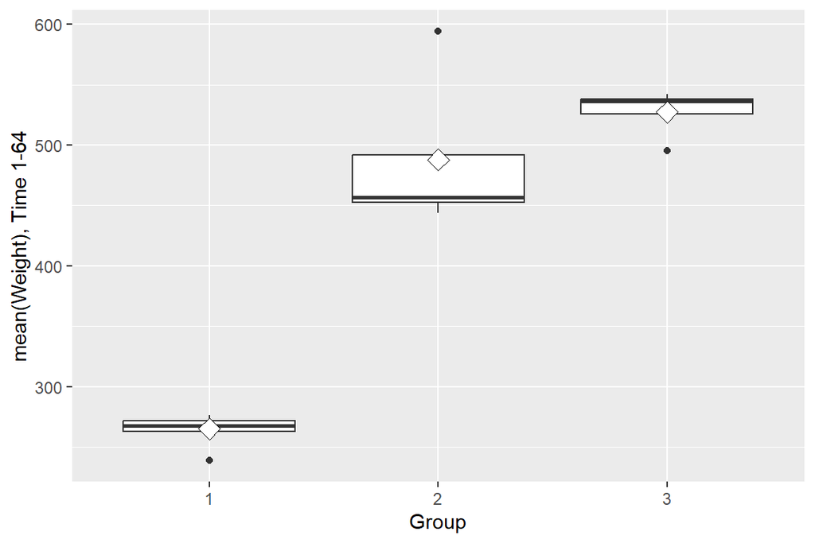

```r
# Draw a boxplot of the mean versus treatment
library(ggplot2)
ggplot(RATSL8S, aes(x = Group, y = mean)) +
  geom_boxplot() +
  stat_summary(fun = "mean", geom = "point", shape=23, size=4, fill = "white") +
  scale_y_continuous(name = "mean(Weight), Time 1-64")
```

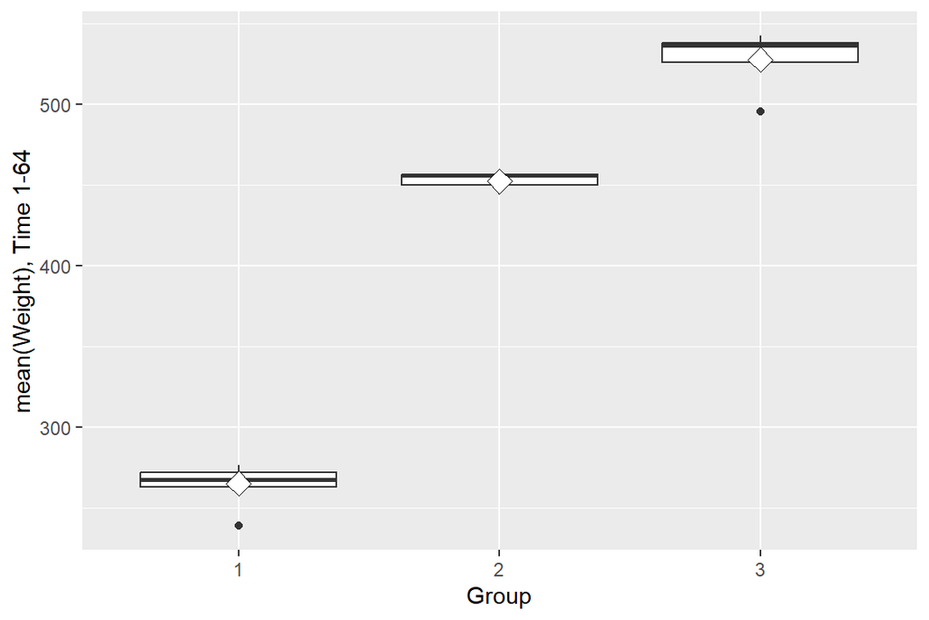

```r
# There seems to be an outlier in group 2
RATSL8S1 <- RATSL8S %>% filter(mean < 560)

# Draw a boxplot without the outlier
library(ggplot2)
ggplot(RATSL8S1, aes(x = Group, y = mean)) +
  geom_boxplot() +
  stat_summary(fun = "mean", geom = "point", shape=23, size=4, fill = "white") +
  scale_y_continuous(name = "mean(Weight), Time 1-64")
```

```r
# Looks better now
```

### T-test and ANOVA of RATS

PBRS data had two groups. Now with multiple groups the two-sample t-test gives an error, however can we use ANOVA (oneway.test) for multiple groups.

```r
# ANOVA
oneway.test(mean ~ Group, data = RATSL8S1, var.equal = TRUE)
```

```
##
##  One-way analysis of means
##
## data:  mean and Group
## F = 501.81, num df = 2, denom df = 12, p-value = 2.721e-12
```

```r
library(dplyr)
library(tidyr)

# for baseline we need the original RATS data
RATS <- read.csv("https://raw.githubusercontent.com/KimmoVehkalahti/MABS/master/Examples/data/rats.txt", header = T, sep = '\t') # separator tab

# Add the baseline from the original data as a new variable to the summary data
RATSL8S2 <- RATSL8S %>%
  mutate(baseline = RATS$WD1)

# Fit the linear model with the mean as the response
fit <- lm(mean ~ baseline + Group, data = RATSL8S2)

# Compute the analysis of variance table for the fitted model with anova()
anova(fit)
```

```
## Analysis of Variance Table
##
## Response: mean
##           Df Sum Sq Mean Sq   F value   Pr(>F)
## baseline   1 253625  253625 1859.8201 1.57e-14 ***
## Group      2    879     439    3.2219  0.07586 .
## Residuals 12   1636     136
## ---
## Signif. codes:  0 '***' 0.001 '**' 0.01 '*' 0.05 '.' 0.1 ' ' 1
```

Based on this only baseline is significantly different. I don’t think that is quite correct, group 1 should definitely be different from the other groups based on the plots. Actually all of the groups should be different from each other.

However, maybe that is because of the baseline. The group 1 starts at a lot lower weight initially than the two other groups and the development is not that different. Why were the group 1 rats so much thinner in the beginning?

## PBRS dataset

### Reading PBRS

Now the BPRS dataset..

```r
# Reading the data
BPRSL <- read.csv("data/bprsl.csv")

#checking the data
glimpse(BPRSL)
```

```
## Rows: 360
## Columns: 5
## $ treatment <int> 1, 1, 1, 1, 1, 1, 1, 1, 1, 1, 1, 1, 1, 1, 1, 1, 1, 1, 1, 1, …
## $ subject   <int> 1, 2, 3, 4, 5, 6, 7, 8, 9, 10, 11, 12, 13, 14, 15, 16, 17, 1…
## $ weeks     <chr> "week0", "week0", "week0", "week0", "week0", "week0", "week0…
## $ bprs      <int> 42, 58, 54, 55, 72, 48, 71, 30, 41, 57, 30, 55, 36, 38, 66, …
## $ week      <int> 0, 0, 0, 0, 0, 0, 0, 0, 0, 0, 0, 0, 0, 0, 0, 0, 0, 0, 0, 0, …
```

```r
# again, the factors seem to be lost in reading, changing them back

BPRSL$treatment <- factor(BPRSL$treatment)
BPRSL$subject <- factor(BPRSL$subject)

# Glimpse the data
glimpse(BPRSL)
```

```
## Rows: 360
## Columns: 5
## $ treatment <fct> 1, 1, 1, 1, 1, 1, 1, 1, 1, 1, 1, 1, 1, 1, 1, 1, 1, 1, 1, 1, …
## $ subject   <fct> 1, 2, 3, 4, 5, 6, 7, 8, 9, 10, 11, 12, 13, 14, 15, 16, 17, 1…
## $ weeks     <chr> "week0", "week0", "week0", "week0", "week0", "week0", "week0…
## $ bprs      <int> 42, 58, 54, 55, 72, 48, 71, 30, 41, 57, 30, 55, 36, 38, 66, …
## $ week      <int> 0, 0, 0, 0, 0, 0, 0, 0, 0, 0, 0, 0, 0, 0, 0, 0, 0, 0, 0, 0, …
```

```r
# Now it seems ok.
```

### Plotting the PBRS

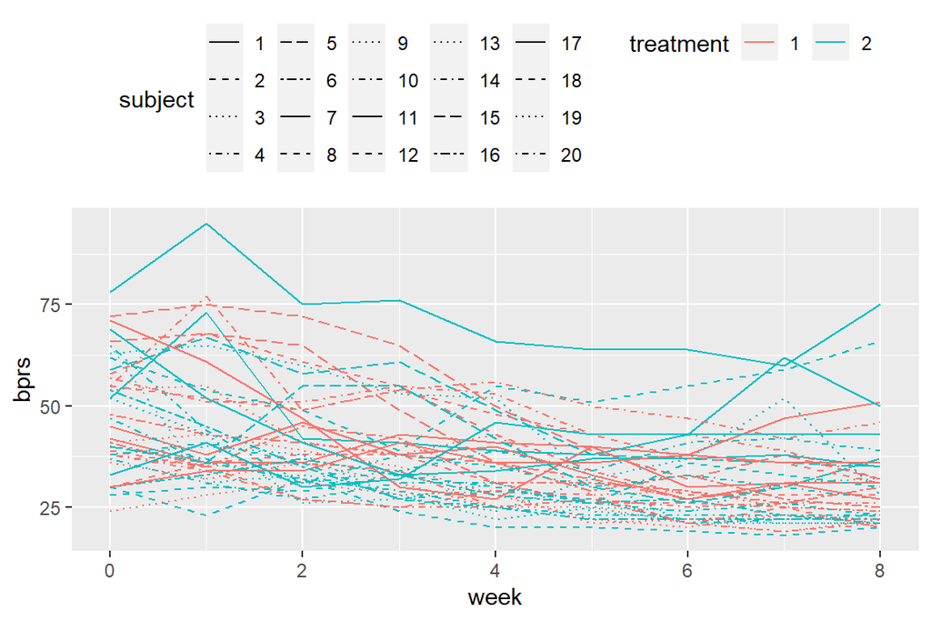

```r
# Draw the plot
ggplot(BPRSL, aes(x = week, y = bprs, linetype = subject, color = treatment)) +
  geom_line() +
  scale_linetype_manual(values = rep(1:10, times=4)) +
  theme(legend.position = "top") +
  scale_y_continuous(limits = c(min(BPRSL$bprs), max(BPRSL$bprs)))
```

Not much difference between the treatments to be seen.

### Regression model

```r
# Work with the exercise in this chunk, step-by-step. Fix the R code!
# RATS and RATSL are available

# create a regression model RATS_reg
BPRS_reg <- lm(bprs ~ week + treatment, data = BPRSL)

# print out a summary of the model
summary(BPRS_reg)
```

```
##
## Call:
## lm(formula = bprs ~ week + treatment, data = BPRSL)
##
## Residuals:
##     Min      1Q  Median      3Q     Max
## -22.454  -8.965  -3.196   7.002  50.244
##
## Coefficients:
##             Estimate Std. Error t value Pr(>|t|)
## (Intercept)  46.4539     1.3670  33.982   <2e-16 ***
## week         -2.2704     0.2524  -8.995   <2e-16 ***
## treatment2    0.5722     1.3034   0.439    0.661
## ---
## Signif. codes:  0 '***' 0.001 '**' 0.01 '*' 0.05 '.' 0.1 ' ' 1
##
## Residual standard error: 12.37 on 357 degrees of freedom
## Multiple R-squared:  0.1851, Adjusted R-squared:  0.1806
## F-statistic: 40.55 on 2 and 357 DF,  p-value: < 2.2e-16
```

Looks like no difference in treatment, but there is a difference between the time points.

So the observations are not independent.

### Random intercept model

```r
# access library lme4
library(lme4)
# Create a random intercept model
BPRS_ref <- lmer(bprs ~ week + treatment + (1 | subject), data = BPRSL, REML = FALSE)

# Print the summary of the model
summary(BPRS_ref)
```

```
## Linear mixed model fit by maximum likelihood  ['lmerMod']
## Formula: bprs ~ week + treatment + (1 | subject)
##    Data: BPRSL
##
##      AIC      BIC   logLik deviance df.resid
##   2748.7   2768.1  -1369.4   2738.7      355
##
## Scaled residuals:
##     Min      1Q  Median      3Q     Max
## -3.0481 -0.6749 -0.1361  0.4813  3.4855
##
## Random effects:
##  Groups   Name        Variance Std.Dev.
##  subject  (Intercept)  47.41    6.885
##  Residual             104.21   10.208
## Number of obs: 360, groups:  subject, 20
##
## Fixed effects:
##             Estimate Std. Error t value
## (Intercept)  46.4539     1.9090  24.334
## week         -2.2704     0.2084 -10.896
## treatment2    0.5722     1.0761   0.532
##
## Correlation of Fixed Effects:
##            (Intr) week
## week       -0.437
## treatment2 -0.282  0.000
```

Fitting the random intercept into the bprs data:

```r
library(lme4)
BPRS_ref1 <- lmer(bprs ~ week + treatment + (week | subject), data = BPRSL, REML = FALSE)

# print a summary of the model
summary(BPRS_ref1)
```

```
## Linear mixed model fit by maximum likelihood  ['lmerMod']
## Formula: bprs ~ week + treatment + (week | subject)
##    Data: BPRSL
##
##      AIC      BIC   logLik deviance df.resid
##   2745.4   2772.6  -1365.7   2731.4      353
##
## Scaled residuals:
##     Min      1Q  Median      3Q     Max
## -2.8919 -0.6194 -0.0691  0.5531  3.7976
##
## Random effects:
##  Groups   Name        Variance Std.Dev. Corr
##  subject  (Intercept) 64.8222  8.0512
##           week         0.9609  0.9802   -0.51
##  Residual             97.4305  9.8707
## Number of obs: 360, groups:  subject, 20
##
## Fixed effects:
##             Estimate Std. Error t value
## (Intercept)  46.4539     2.1052  22.066
## week         -2.2704     0.2977  -7.626
## treatment2    0.5722     1.0405   0.550
##
## Correlation of Fixed Effects:
##            (Intr) week
## week       -0.582
## treatment2 -0.247  0.000
```

```r
# perform an ANOVA test on the two models
anova(BPRS_ref1, BPRS_ref)
```

```
## Data: BPRSL
## Models:
## BPRS_ref: bprs ~ week + treatment + (1 | subject)
## BPRS_ref1: bprs ~ week + treatment + (week | subject)
##           npar    AIC    BIC  logLik deviance  Chisq Df Pr(>Chisq)
## BPRS_ref     5 2748.7 2768.1 -1369.4   2738.7
## BPRS_ref1    7 2745.4 2772.6 -1365.7   2731.4 7.2721  2    0.02636 *
## ---
## Signif. codes:  0 '***' 0.001 '**' 0.01 '*' 0.05 '.' 0.1 ' ' 1
```

The chi squared is statistically significant (0.02636), but the model is not as good fit as it was in the Excersize set with RATS data.

```r
library(lme4)
BPRS_ref2 <- lmer(bprs ~ week + treatment + week * treatment + (1 | subject), data = BPRSL, REML = FALSE)

# print a summary of the model
summary(BPRS_ref2)
```

```
## Linear mixed model fit by maximum likelihood  ['lmerMod']
## Formula: bprs ~ week + treatment + week * treatment + (1 | subject)
##    Data: BPRSL
##
##      AIC      BIC   logLik deviance df.resid
##   2747.7   2771.1  -1367.9   2735.7      354
##
## Scaled residuals:
##     Min      1Q  Median      3Q     Max
## -3.2038 -0.6641 -0.0846  0.4837  3.6049
##
## Random effects:
##  Groups   Name        Variance Std.Dev.
##  subject  (Intercept)  47.46    6.889
##  Residual             103.31   10.164
## Number of obs: 360, groups:  subject, 20
##
## Fixed effects:
##                 Estimate Std. Error t value
## (Intercept)      47.8856     2.0795  23.027
## week             -2.6283     0.2934  -8.958
## treatment2       -2.2911     1.9755  -1.160
## week:treatment2   0.7158     0.4149   1.725
##
## Correlation of Fixed Effects:
##             (Intr) week   trtmn2
## week        -0.564
## treatment2  -0.475  0.594
## wek:trtmnt2  0.399 -0.707 -0.840
```

```r
# perform an ANOVA test on the two models
anova(BPRS_ref2, BPRS_ref1)
```

```
## Data: BPRSL
## Models:
## BPRS_ref2: bprs ~ week + treatment + week * treatment + (1 | subject)
## BPRS_ref1: bprs ~ week + treatment + (week | subject)
##           npar    AIC    BIC  logLik deviance Chisq Df Pr(>Chisq)
## BPRS_ref2    6 2747.8 2771.1 -1367.9   2735.8
## BPRS_ref1    7 2745.4 2772.6 -1365.7   2731.4 4.309  1    0.03791 *
## ---
## Signif. codes:  0 '***' 0.001 '**' 0.01 '*' 0.05 '.' 0.1 ' ' 1
```

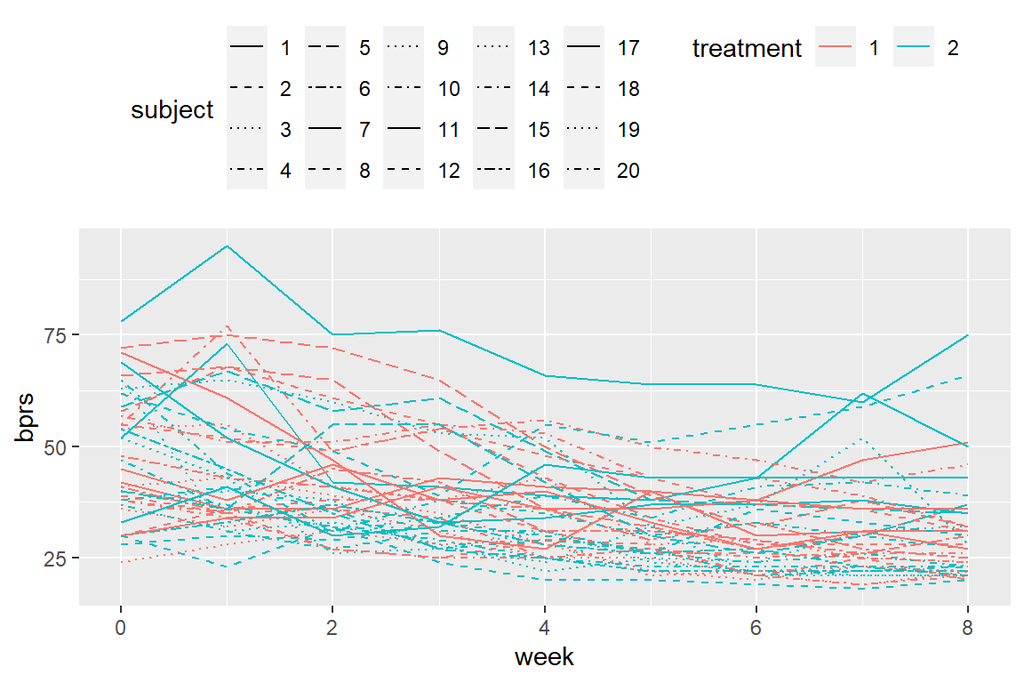

```r
# draw the plot of RATSL with the observed Weight values
ggplot(BPRSL, aes(x = week, y = bprs, linetype = subject, color = treatment)) +
  geom_line() +
  scale_linetype_manual(values = rep(1:10, times=4)) +
  theme(legend.position = "top") +
  scale_y_continuous(limits = c(min(BPRSL$bprs), max(BPRSL$bprs)))
```

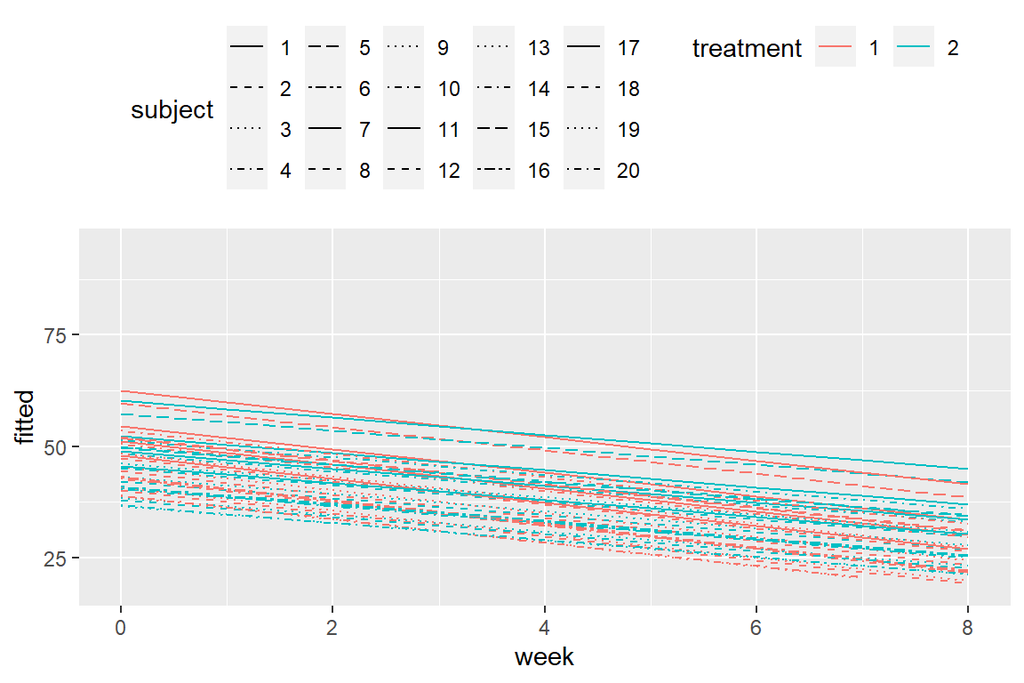

```r
# Create a vector of the fitted values
fitted <- fitted(BPRS_ref2)

library(dplyr)
library(tidyr)
# Create a new column fitted to RATSL
BPRSL <- BPRSL %>%
  mutate(fitted = fitted)

# draw the plot of BPRSL with the Fitted values of weight
ggplot(BPRSL, aes(x = week, y = fitted, linetype = subject, color = treatment)) +
  geom_line() +
  scale_linetype_manual(values = rep(1:10, times=4)) +
  theme(legend.position = "top") +
  scale_y_continuous(limits = c(min(BPRSL$bprs), max(BPRSL$bprs)))
```

Looks like no difference.